# Spatial Temporal Diversity By Strata

Here, we will do a similar analysis but by strata instead of subregion

```r
library(data.table)
library(ggplot2)
library(geosphere)
library(betapart)
```

Data

```r
load("NE_trawl_data_full.Rdata")
```

# Distance Decay with Stratum instead of region

Jaccard Dissimilarities Distance Decay all in one plot by STRATA

| strat1 | strat2 | distance(m) |
| --- | --- | --- |
| 1020 | 1020 | 0.00 |
| 1030 | 1020 | 81429.83 |
| 1040 | 1020 | 85724.66 |
| 1070 | 1020 | 106130.10 |
| 1080 | 1020 | 136231.17 |
| 1120 | 1020 | 274929.85 |
| 1130 | 1020 | 385331.94 |
| 1140 | 1020 | 434809.70 |
| 1150 | 1020 | 413133.12 |
| 1180 | 1020 | 549052.53 |

[output cut: 990 more lines]

Above is distance info, now I need to build community matrix

```r
#one PRESENT value for each YEAR, SEASON, STRATUM and SVSPP combination
neus_full.ID.stratum.unique <- na.omit(unique(neus_full.ID, by = c("YEAR", "STRATUM", "SVSPP")), cols = c("YEAR", "STRATUM", "SVSPP")) #unique STRATUM, year, species combinations, and get rid of any rows where any are NA
#reduce data table to just be svspp, year, sciname, comname, STRATUM
neus_full.ID.stratum.unique.r <- data.table((neus_full.ID.stratum.unique[, c("SVSPP", "SCINAME", "COMNAME", "YEAR", "STRATUM")]))
#add presence column
neus_full.ID.stratum.unique.r[,"present" := 1]
#now I need to populate a comparison data table with every possible year, region, and species combination to add 0s
stratum <- as.integer(unique(neus_full.ID.stratum.unique.r$STRATUM))
full_set_stratum<- data.table(expand.grid("SVSPP" = spp.list, "YEAR" = years, "STRATUM" = stratum))
```

Bring in presences to expansion for presence by STRATUM

```r
merge <- neus_full.ID.stratum.unique.r[full_set_stratum, on = c("YEAR", "STRATUM", "SVSPP")]
merge[,"present" := ifelse(is.na(SCINAME), 0,1)][,"SCINAME" := NULL][,"COMNAME" := NULL] #if scientific name and common name are empty, that is an absence, if populated, presence, also, we don't need these columns, as we'll bring them in below
#simplify spp key
#bring in spp key
spp_key
```

| SVSPP | SCINAME | COMNAME |
| --- | --- | --- |
| 1 | MYXINE GLUTINOSA | ATLANTIC HAGFISH |
| 2 | PETROMYZON MARINUS | SEA LAMPREY |
| 3 | CARCHARHINUS OBSCURUS | DUSKY SHARK |
| 4 | DASYATIS CENTROURA | ROUGHTAIL STINGRAY |
| 5 | RAJIFORMES | RAY AND SKATE UNCL |
| 6 | CETORHINUS MAXIMUS | BASKING SHARK |
| 7 | CENTROSCYLLIUM FABRICII | BLACK DOGFISH |
| 8 | ETMOPTERUS PRINCEPS | ROUGH SAGRE |
| 9 | CARCHARHINUS PLUMBEUS | SANDBAR SHARK |
| 11 | SELACHIMORPHA | SHARK UNCL |

[output cut: 807 more lines]

```r
neus_pres_abs_STRATUM <- merge[spp_key, on = c("SVSPP")] #also don't actually need all columns
```

Make distance decay model for each year by loop for all STRATUM, YEAR, SVSPP combos. I’ve commented out lines that attempt to make a distance decay model because of error. Instead, I will just use this loop to populate a data table with distance and dissimilarities between all strata. I attempt to use decay.model() function from betapart package. –> I can’t get this to work Error: *cannot find valid starting values: please specify some*

```r
distances_dissimilarities_allyears_STRATUM <- data.table("strat1" = integer(), "strat2" = integer(), "distance(m)" = numeric(),"jaccard_dissimilarity" = numeric(), YEAR = integer())
#Now loop through all years starting in 1967
for (i in 1:length(years)) {
  reduced_year <- neus_pres_abs_STRATUM[YEAR == years[i],]
  reduced_year_wide <- dcast(reduced_year, YEAR + STRATUM ~ SCINAME, value.var = "present") #long to wide data for community matrix, column names are SVSPP

  communitymatrix <- cbind(reduced_year_wide[,c(3:819)], reduced_year_wide[,c(1:2)]) #community matrix

#there are some STRATA with no presences or observations
#rowSums(communitymatrix.r[,c(1:817)]) #I guess I will get rid of those
communitymatrix.r <- communitymatrix[as.logical(rowSums(communitymatrix[,c(1:817)] != 0)), ] #reduce to only rows with atleast one species present
stratum.r <- communitymatrix.r$STRATUM

  dissimilarities <- vegdist(communitymatrix.r[,c(1:817)], method = "jaccard", binary = T) #dissimilarity

#make into matrix
dissimilarities.m <- as.matrix(dissimilarities, labels=TRUE)
colnames(dissimilarities.m) <- rownames(dissimilarities.m) <- stratum.r
  #reshape dissimilarities
  dissimilarities.l <- melt(dissimilarities.m, varnames = c("strat1", "strat2"))
  dissimilarities.l <- data.table(dissimilarities.l) #and then to data table
  dissimilarities.l <- dissimilarities.l[strat1 >= strat2,] # to get rid of repetitions
  colnames(dissimilarities.l)[colnames(dissimilarities.l)=="value"] <- "jaccard_dissimilarity" #change column name to distance
#add year for these values
  dissimilarities.l[, "YEAR" := years[i]]
#merge distance with jaccard_dissimilarity for this year
  dissimilarities.l.full <- stratum_distance.l[dissimilarities.l, on = c("strat1", "strat2")]
distances_dissimilarities_allyears_STRATUM <- rbind(distances_dissimilarities_allyears_STRATUM, dissimilarities.l.full) #add to data table
#extract info for distance decay exponential model for each year
#reduce stratum_distances to stratum.r
stratum_distances.r <- stratum_distances[as.character(stratum.r), as.character(stratum.r)]
#modname <- paste0(years[i], "_decay_mod_exponential")
#assign(modname, decay.model(dissimilarities.m, stratum_distances.r, model.type = "exponential", y.type = "dissimilarities", perm = 100))
#jpeg(file=paste0("jaccardplot_", years[i], ".jpg"))
    #plot(x=dissimilarities.l.full$`distance(m)`, y=dissimilarities.l.full$jaccard_dissimilarity, xlab = "Distance(m)", #ylab="Jaccard dissimilarity", ylim = c(0:1), pch = 19)
 #dev.off()

 #PCA
#vare.pca <- rda(communitymatrix[,c(1:817)])
#jpeg(file=paste0("jaccardpca_", years[i], ".jpg"))
#plot(vare.pca, display = "sites", xlim = c(-4,4), ylim = c(-4,4))
#dev.off()

}
summary(distances_dissimilarities_allyears_STRATUM) #here we have jaccard, distance, and
```

```
     strat1         strat2      distance(m)      jaccard_dissimilarity      YEAR
 Min.   :1010   Min.   :1010   Min.   :      0   Min.   :0.0000        Min.   :1967
 1st Qu.:1750   1st Qu.:1160   1st Qu.: 210351   1st Qu.:0.6616        1st Qu.:1980
 Median :3290   Median :1350   Median : 398545   Median :0.7955        Median :1990
 Mean   :3682   Mean   :1897   Mean   : 461207   Mean   :0.7570        Mean   :1991
 3rd Qu.:3590   3rd Qu.:3030   3rd Qu.: 659516   3rd Qu.:0.8909        3rd Qu.:2002
 Max.   :8930   Max.   :8930   Max.   :2233130   Max.   :1.0000        Max.   :2018
```

```r
save(distances_dissimilarities_allyears, file = "jaccard_similarities_distances_4reg.Rdata")
save(distances_dissimilarities_allyears_STRATUM, file = "jaccard_similarities_distances_stratum.Rdata")
```

Instead, I will look at distance decay through time visually

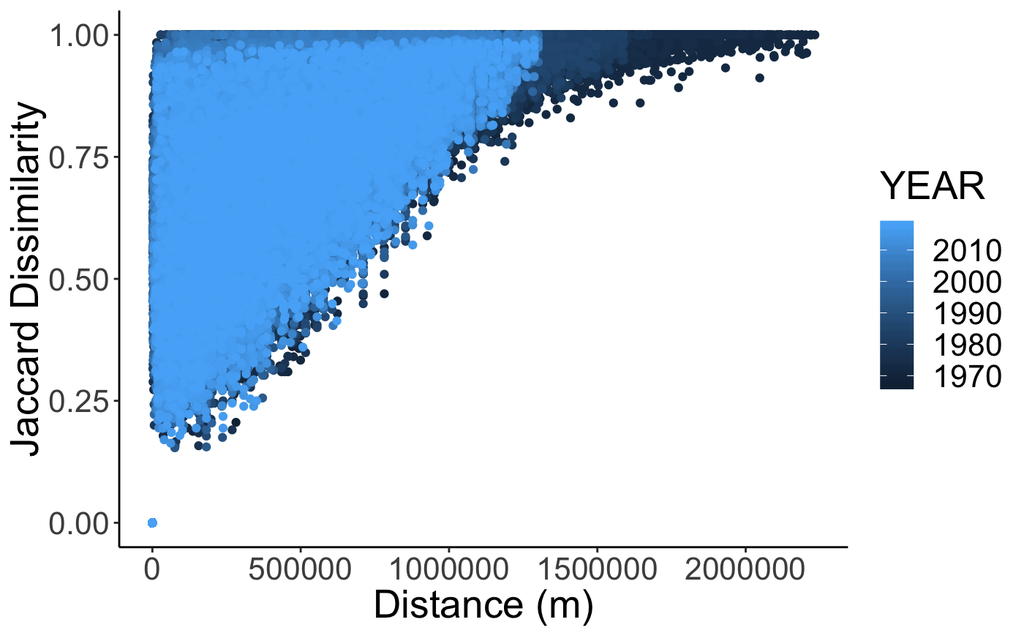

Extract coefficient (slope) for each year for simple exponential, how does it change through time? I did this because I couldn’t get betapart decay.model to work.

```r
#I'm interested in the rate of decrease
#make new column for 1-jaccard dissimilarity
distances_dissimilarities_allyears_STRATUM[,jaccard_similarity := 1-jaccard_dissimilarity]
#reduce to one year
expmod_coefs <- data.table("year" = years, "beta.0" = 0)
for (i in 1:length(years)) {
  reduced <- distances_dissimilarities_allyears_STRATUM[YEAR == years[i],]

  # Select an approximate $\theta$, since theta must be lower than min(y), and greater than zero
theta.0 <- min(reduced[jaccard_similarity != 0,]$jaccard_similarity) * 0.5
# Estimate the rest parameters using a linear model
model.0 <- lm(log(jaccard_similarity - theta.0) ~ `distance(m)`, data=reduced)
alpha.0 <- exp(coef(model.0)[1])
beta.0 <- coef(model.0)[[2]]
expmod_coefs[i,2] <- -(beta.0)
}
```

[output not shown]

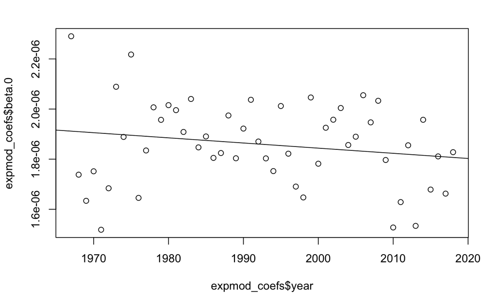

```r
plot(expmod_coefs$year, expmod_coefs$beta.0)
abline(lm(expmod_coefs$beta.0~expmod_coefs$year))
```

```r
#decreasing in rate of decay through time
```

Below, I continue to attempt to make distance decay from betapart package work, no luck yet. Some years work, others don’t

Fitting distance decay models to pair-wise assemblage similarity: fits a negative exponential or power law function(GLM) describing decay of assemblage similarity or increase of dissimilarity with distance.

```r
#haven't figured out error here, same error that appears above
#reduce stratum_distances to stratum.r
stratum_distances.r <- stratum_distances[as.character(stratum.r), as.character(stratum.r)]
mod_1968 <- decay.model(dissimilarities.m, stratum_distances.r, model.type = "exponential", y.type = "dissimilarities", perm = 1000)
```

```
Error in eval(family$initialize) :
  cannot find valid starting values: please specify some
```